# Analyses with Semantic Scholar

# SEMANTIC SCHOLAR

```r
library(dplyr)
library(reshape)
library(ggplot2)
library(hrbrthemes)
library(ggpubr)
library(tidyr)
library(stringr)
library(ggrepel)
library(readxl)
source("Functions.R")
```

Some parameters for the plots:

```r
my.theme<-theme(axis.text=element_text(size=15),
        axis.title = element_text(size = 17),
        legend.text=element_text(size=10),
        legend.title = element_text(size=12),
        plot.title = element_text(face="bold",size=14,margin=margin(0,0,20,0),hjust = 0.5),
        axis.title.y = element_text(margin = margin(t = 0, r = 10, b = 0, l = 0)),
        axis.title.x = element_text(margin = margin(t = 15, r = 0, b = 0, l = 0)),
        panel.background = element_rect(fill = 'white'))
```

#### Read data

```r
dataset_repos <- read_excel("df_repository.xlsx")

dataset_repos <- dataset_repos[which(dataset_repos$title != ""),]
dataset_repos <- dataset_repos %>% dplyr::filter(valid_yn == "yes")

head(dataset_repos)
```

| url | title | full_text | publication_date | id_query | reason_non_valid | valid_yn | dataset_relevance | dataset_location | dataset_format | geospatial_info_dataset | geospatial_info_repo_page_text | geospatial_info_article_text | species | species_location | species_group_location | temporal_range | temporal_range_position | temporal_duration_y | temporal_duration_position | spatial_range_km2 | spatial_range_position | data_type | data_type_location | referred_dataset | relevance_referred_dataset | journal | publication_year | comments | source | … |
| --- | --- | --- | --- | --- | --- | --- | --- | --- | --- | --- | --- | --- | --- | --- | --- | --- | --- | --- | --- | --- | --- | --- | --- | --- | --- | --- | --- | --- | --- | --- |
| https://doi.org/10.5061/dryad.05qfttf0n | Fish mock community with 41 species from 13 orders | Fish mock community with 41 species from 13 orders Tissue extracts of 41 North American fish species were obtained from the Ministère des Forêts, de la Faune et des Parcs (Québec). The selected specie… | 2020-08-16 | 3 | NA | yes | X | NA | NA | no | no | NA | 41 fish mock species | NA | NA | NA | NA | NA | NA | no | NA | genetic analysis | NA | NA | NA | no | NA | No link to any publication | zenodo | … |
| https://doi.org/10.5061/dryad.0rxwdbs2c | Exploration and diet specialization in eastern chipmunks - Québec - Canada | Exploration and diet specialization in eastern chipmunks - Québec - Canada From 2012 to 2016, we live-trapped wild eastern chipmunks, Tamias striatus, within three sites near Mansonville, southern Qué… | 2022-03-08 | 3,7,4,6 | NA | yes | L | repository | .csv | administrative unit | Administrative unit | NA | Tamias striatus | NA | NA | 2012-2017 | source link abstract, dataset | 5 | no | 0.2 | no | presence only | NA | NA | NA | The American Naturalist | NA | No source publication. Locality is mentioned in the README among the datasets files (this happens a lot). A note to take this as an example of text where different temporal tanges are given, which may… | zenodo | … |
| https://doi.org/10.5061/dryad.121sk | Data from: Paternity analysis of wood turtles (Glyptemys insculpta) reveals complex mating patterns | Data from: Paternity analysis of wood turtles (Glyptemys insculpta) reveals complex mating patterns Mating system characteristics are of great importance as they may influence male and female reproduc… | 2017-10-26 | 3,8 | NA | yes | M | repository | .xlsx | no | geological feature me | geological feature me | Glyptemys insculpta | NA | NA | 2006-2007 | source link abstract | 1 | no | no | no | EBV genetic analysis | NA | NA | NA | Journal of Heredity | NA | Endangered species. Locality mentioned in the text of the source link (Shawinigan River (Québec)) | zenodo | … |
| https://doi.org/10.5061/dryad.12jm63xtw | Data from: 60 specific eDNA qPCR assays to detect invasive, threatened and exploited freshwater vertebrates and invertebrates in Eastern Canada | Data from: 60 specific eDNA qPCR assays to detect invasive, threatened and exploited freshwater vertebrates and invertebrates in Eastern Canada Practical applications of environmental DNA (eDNA) are i… | 2020-05-04 | 3,8 | NA | yes | X | repository | NA | NA | NA | NA | 40 freshwater vertebrate and invertebrates | NA | NA | NA | NA | NA | NA | NA | NA | other | NA | NA | NA | Environmental DNA | 2020 | NA | zenodo | … |
| https://doi.org/10.5061/dryad.15dv41p1m | A basic community dynamics experiment: Disentangling deterministic and stochastic processes in structuring ecological communities | A basic community dynamics experiment: Disentangling deterministic and stochastic processes in structuring ecological communities Source community\r\r\nThe source plant community was isolated from a e… | 2022-12-26 | 3,4,8,10 | NA | yes | L | NA | NA | NA | site coordites | site coordites | Lemna minor, Lemna trisulca, Spirodela polyrhiza,Wolffia columbiana | NA | NA | NA | NA | <1 | NA | 0.5 | NA | presence only | NA | NA | NA | Ecology and Evolution | NA | dataset not useful because its a non-field experiment. Here I noted the presence of species sampled for the experiment | zenodo | … |
| https://doi.org/10.5061/dryad.1771t | Data from: Resampling method for applying density-dependent habitat selection theory to wildlife surveys | Data from: Resampling method for applying density-dependent habitat selection theory to wildlife surveys Isodar theory can be used to evaluate fitness consequences of density-dependent habitat selecti… | 2016-05-07 | 0,3,4,8,10 | NA | yes | L | repository | .xlsx | sample coordites | NA | site coordites, Map | raccoons, striped skunks | NA | NA | 2008 | source publication text, dataset | <1 | source publication text | no | no | density | NA | NA | NA | Plos One | NA | NA | zenodo | … |

```r
table(dataset$valid_yn)
```

```
 no yes
 43 140
```

```r
table(dataset$reason_non_valid[which(dataset$valid_yn=="no")])
```

```
    experiment       location      location   no biological non biological
             1             27              1              2              1
         other
            11
```

## 1. Number of datasets and relevance categories

Only Semantic Schoar

```r
df_N_relevance <- count_by_relevance(dataset)

df_N_relevance
```

|  | dataset relevance | N |
| --- | --- | --- |
| 5 | No dataset | 59 |
| 3 | L | 28 |
| 4 | M | 21 |
| 1 | cant access | 20 |
| 6 | X | 9 |
| 2 | H | 3 |

### 1.1 Relevance counts by source

(only when comparing semantic scholar with repos)

|  | relevance | dryad | semantic_scholar | zenodo | repositories |
| --- | --- | --- | --- | --- | --- |
| 2 | H | 10 | 3 | 11 | 21 |
| 4 | M | 13 | 21 | 21 | 34 |
| 3 | L | 16 | 28 | 24 | 40 |
| 6 | X | 3 | 9 | 13 | 16 |
| 5 | No dataset | 0 | 59 | 0 | 0 |
| 1 | cant access | 0 | 20 | 1 | 1 |

Plot the results:

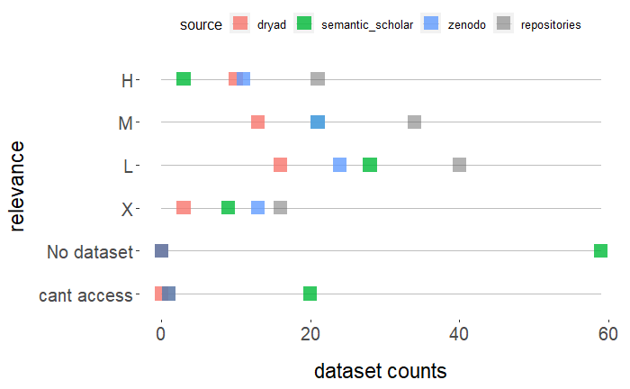

## Data Format

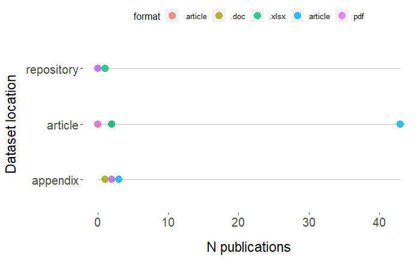

## 10. Source of information across time

|  | publication_date | source | year |
| --- | --- | --- | --- |
| 1 | 13/9/2021 | dryad | 2021 |
| 2 | 7/5/2016 | dryad | 2016 |
| 3 | 28/8/2016 | dryad | 2016 |
| 4 | 27/12/2018 | dryad | 2018 |
| 5 | 25/4/2018 | dryad | 2018 |
| 6 | 11/3/2016 | dryad | 2016 |
| 8 | 13/8/2015 | dryad | 2015 |
| 9 | 17/3/2015 | dryad | 2015 |
| 10 | 17/3/2015 | dryad | 2015 |
| 11 | 23/1/2017 | dryad | 2017 |

[output cut: 137 more lines]

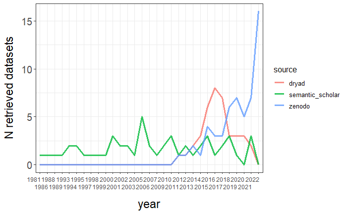

# location - dataset type

We evaluate the feasibility to automatically retrieve the information on the dataset type by looking at whether authors make explicit the type of dataset in either the title or abstract.

Type of dataset should fall in one of the following categories or synonyms:

```r
df_dataset_types <- read.csv("../data/dataset_types.csv", sep = ";")
df_dataset_types
```

| type_dataset | keywords | keywords_type |
| --- | --- | --- |
| presence only | presence only | synonym |
| presence only | occurrence | synonym |
| presence only | specimen records | synonym |
| presence only | specimen | synonym |
| presence only | collection | synonym |
| presence-absence | presence-absence | synonym |
| presence-absence | sampling plot | methods |
| presence-absence | relative proportion | methods |
| presence-absence | inventory | methods |
| presence-absence | occupancy | methods |

[output cut: 16 more lines]

I will add the following synonyms:

presence-absence: detection, capture

```r
df_dataset_types[nrow(df_dataset_types)+1,] <- c("presence-absence", "detection", "synonym")
df_dataset_types[nrow(df_dataset_types)+1,] <- c("presence-absence", "capture", "synonym")

df_dataset_types[nrow(df_dataset_types)+1,] <- c("EBV genetic analyses", "16S", "methods")
df_dataset_types[nrow(df_dataset_types)+1,] <- c("EBV genetic analyses", "18S", "methods")
df_dataset_types[nrow(df_dataset_types)+1,] <- c("EBV genetic analyses", "barcodes", "methods")
df_dataset_types[nrow(df_dataset_types)+1,] <- c("EBV genetic analyses", "haplotypes", "methods")
df_dataset_types[nrow(df_dataset_types)+1,] <- c("EBV genetic analyses", "eDNA", "methods")
df_dataset_types[nrow(df_dataset_types)+1,] <- c("EBV genetic analyses", "SNPs", "methods")

df_dataset_types
```

|  | type_dataset | keywords | keywords_type |
| --- | --- | --- | --- |
| 1 | presence only | presence only | synonym |
| 2 | presence only | occurrence | synonym |
| 3 | presence only | specimen records | synonym |
| 4 | presence only | specimen | synonym |
| 5 | presence only | collection | synonym |
| 6 | presence-absence | presence-absence | synonym |
| 7 | presence-absence | sampling plot | methods |
| 8 | presence-absence | relative proportion | methods |
| 9 | presence-absence | inventory | methods |
| 10 | presence-absence | occupancy | methods |

[output cut: 24 more lines]

### FOR REPOSITORIES ONLY

Detecting the words in title or abstract

```r
url <- c()
dataset_type <- c()
keyword_abs <- list()
keyword_title <- list()
#keyword_type <- c()
in_title <- c()
in_abstract <- c()



for (i in 1:nrow(dataset_repos)) {



  dataset_type[i] <- dataset_repos[i, "data_type"]
  url[i] <- dataset_repos[i, "url"]




  # search on the abstract and note the list of keywords that match the dataset types

  keyword_abs[[i]] <- unique(get_keywords(input_string = dataset_repos$full_text[i],
               dataset_types =  df_dataset_types))

  # if the list of keywords has 1 or more entry, then note that we found information in the abstract

  if(length(keyword_abs[i][!sapply(keyword_abs[i], is.null)]) == 0){

    in_abstract[i] <- "no"

  } else if (length(keyword_abs[i][!sapply(keyword_abs[i], is.null)]) > 0){

    in_abstract[i] <- "yes"

  }




  # search on the title and note the list of keywords that match the dataset types

  keyword_title[[i]] <- unique(get_keywords(input_string = dataset_repos$title[i],
               dataset_types =  df_dataset_types))

  # if the list of keywords has 1 or more entry, then note that we found information in the abstract

  if(length(keyword_title[i][!sapply(keyword_title[i], is.null)]) == 0){

    in_title[i] <- "no"

  } else if (length(keyword_title[i][!sapply(keyword_title[i], is.null)]) > 0){

    in_title[i] <- "yes"

  }



}
```

For some reason, keyword_title has 3 less entries that keyword_abstract, and I can’t figure out why. So for now I cant obtain the list of words that appear in the title.

```r
print(paste(length(which(in_abstract == "yes")),
            "with dataset type or synonym explicit in the abstract, out of", length(in_abstract)))
```

```
[1] "95 with dataset type or synonym explicit in the abstract, out of 108"
```

```r
print(paste("so",
      round(length(which(in_abstract == "yes"))/length(in_abstract)*100, 1),
"%"))
```

```
[1] "so 88 %"
```

```r
print(paste(length(which(in_title == "yes")),
            "with dataset type or synonym explicit in the title, out of", length(in_title)))
```

```
[1] "26 with dataset type or synonym explicit in the title, out of 108"
```

```r
print(paste("so",
      round(length(which(in_title == "yes"))/length(in_title)*100, 1),
"%"))
```

```
[1] "so 24.1 %"
```

### Repeat for SEMANTIC SCHOLAR only

Detecting the words in title or abstract

```r
url <- c()
dataset_type <- c()
keyword_abs <- list()
keyword_title <- list()
#keyword_type <- c()
in_title <- c()
in_abstract <- c()



for (i in 1:nrow(dataset)) {



  dataset_type[i] <- dataset[i, "data_type"]
  url[i] <- dataset[i, "url"]




  # search on the abstract and note the list of keywords that match the dataset types

  keyword_abs[[i]] <- unique(get_keywords(input_string = dataset$description[i],
               dataset_types =  df_dataset_types))

  # if the list of keywords has 1 or more entry, then note that we found information in the abstract

  if(length(keyword_abs[i][!sapply(keyword_abs[i], is.null)]) == 0){

    in_abstract[i] <- "no"

  } else if (length(keyword_abs[i][!sapply(keyword_abs[i], is.null)]) > 0){

    in_abstract[i] <- "yes"

  }




  # search on the title and note the list of keywords that match the dataset types

  keyword_title[[i]] <- unique(get_keywords(input_string = dataset$title[i],
               dataset_types =  df_dataset_types))

  # if the list of keywords has 1 or more entry, then note that we found information in the abstract

  if(length(keyword_title[i][!sapply(keyword_title[i], is.null)]) == 0){

    in_title[i] <- "no"

  } else if (length(keyword_title[i][!sapply(keyword_title[i], is.null)]) > 0){

    in_title[i] <- "yes"

  }



}
```

For some reason, keyword_title has 3 less entries that keyword_abstract, and I can’t figure out why. So for now I cant obtain the list of words that appear in the title.

```r
print(paste(length(which(in_abstract == "yes")),
            "with dataset type or synonym explicit in the abstract, out of", length(in_abstract)))

print(paste("so",
      round(length(which(in_abstract == "yes"))/length(in_abstract)*100, 1),
"%"))
```

[output not shown]

```r
print(paste(length(which(in_title == "yes")),
            "with dataset type or synonym explicit in the title, out of", length(in_title)))

print(paste("so",
      round(length(which(in_title == "yes"))/length(in_title)*100, 1),
"%"))
```

[output not shown]